# Kapitola 13: Cvičenia 13.6 - 13.9

Bayesovská logistická regresia - Hotel Bookings

Dana Kozáková

2025-12-03

# Načítanie balíkov

### Interpretácia koeficientov

**Intercept $\beta_0$:**

- Na log(odds) škále: $\beta_0$ je log(odds) zrušenia pri všetkých $X_k = 0$
- Na odds škále: $e^{\beta_0}$ sú odds zrušenia pri všetkých $X_k = 0$

**Sklon $\beta_k$ (k = 1, 2, 3, 4):**

- Na log(odds) škále: $\beta_k$ je zmena v log(odds) pri zvýšení $X_k$ o 1
- Na odds škále: $e^{\beta_k}$ je **multiplikatívna zmena** v odds pri zvýšení $X_k$ o 1

$$e^{\beta_k} =
\frac{\text{odds}_{x+1}}{\text{odds}_x}$$

**Príklad:** Ak $\beta_2 = 0.5$, potom: - Log(odds) sa zvýšia o 0.5 - Odds sa vynásobia $e^{0.5} = 1.65$ (zvýšia sa o 65%)

### Apriorné rozdelenia

$$\begin{aligned}
\beta_{0c} &\sim N(-1.4, 0.7^2) \\
\beta_k &\sim N(0, 1^2) \text{ s autoscale=TRUE, } k = 1, 2, 3, 4
\end{aligned}$$

# Zadanie: Hotel Bookings

Analyzuj údaje o hotelových rezerváciách v datasete `hotel_bookings` z balíka `bayesrules`. Dáta obsahujú náhodný výber rezervácií zhromaždených Antoniom, de Almeidou a Nunesom (2019).

## Premenné

| Premenná | Označenie | Význam |
| --- | --- | --- |
| `is_canceled` | $Y$ | či bola rezervácia zrušená |
| `lead_time` | $X_1$ | počet dní medzi rezerváciou a plánovaným príchodom |
| `previous_cancellations` | $X_2$ | počet predchádzajúcich zrušení hosťa |
| `is_repeated_guest` | $X_3$ | či je hosť opakujúci sa zákazník hotela |
| `average_daily_rate` | $X_4$ | priemerná denná cena hotela |

# Cvičenie 13.6: Príprava dát a explorácia

```r
# load data
data(hotel_bookings)

# vyber len vhodne stlpce
hotel <- hotel_bookings %>%
  select(is_canceled, lead_time, previous_cancellations,
         is_repeated_guest, average_daily_rate)
```

## Úloha 13.6a)

**a)** Aký podiel rezervácií v datasete bol zrušený?

```r
hotel %>% tabyl(is_canceled)
```

```
##  is_canceled   n percent
##            0 634   0.634
##            1 366   0.366
```

## Úloha 13.6b)

**b)** Vytvor a diskutuj grafy `is_canceled` verzus každý z prediktorov.

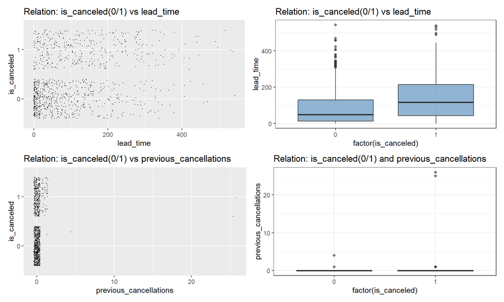

```r
# visualisation
# jitter pre lead_time
plt_j <- ggplot(hotel, aes(x = lead_time, y = is_canceled)) +
  geom_jitter(size = 0.2) +
  labs(title = 'Relation: is_canceled(0/1) vs lead_time')
# boxplot pre lead_time
plt_b <- ggplot(hotel, aes(x = factor(is_canceled), y = lead_time)) +
  geom_boxplot(fill = "steelblue", alpha = 0.6) +
  labs(title = "Relation: is_canceled(0/1) vs lead_time") +
  theme_bw()

# jitter pre previous cancellations
ppc_j <- ggplot(hotel, aes(x = previous_cancellations, y = is_canceled)) +
  geom_jitter(size = 0.2) +
  labs(title = 'Relation: is_canceled(0/1) vs previous_cancellations')
# boxplot pre previous cancellations
ppc_b <- ggplot(hotel, aes(x = factor(is_canceled), y = previous_cancellations)) +
  geom_boxplot(fill = "steelblue", alpha = 0.6) +
  labs(title = "Relation: is_canceled(0/1) and previous_cancellations") +
  theme_bw()

# jitter pre repeated_guest
prq_j <- ggplot(hotel, aes(x = is_repeated_guest, y = is_canceled)) +
  geom_jitter(size = 0.2) +
  labs(title = 'Relation: is_canceled(0/1) and is_repeated_guest')
# bar pre repeated_quest
prq_b <- hotel %>%
  group_by(is_repeated_guest, is_canceled) %>%
  summarise(n = n()) %>%
  group_by(is_repeated_guest) %>%
  mutate(prop = n/sum(n)) %>%
  filter(is_canceled == 1) %>%
  ggplot(aes(x = factor(is_repeated_guest), y = prop)) +
  geom_col(fill = "darkorange", alpha = 0.7) +
  labs(x = "repeated_guest", y = "is_cancelled",
       title = "Relation: is_canceled(0/1) and is_repeated_guest") +
  theme_minimal()

# jitter pre average_daily_rate
padr_j <- ggplot(hotel, aes(x = average_daily_rate, y = is_canceled)) +
  geom_jitter(size = 0.2) +
  labs(title = 'Relation: is_canceled(0/1) and average_daily_rate')
# boxplot pre average_daily_rate
padr_b <- ggplot(hotel, aes(x = factor(is_canceled), y = average_daily_rate)) +
  geom_boxplot(fill = "steelblue", alpha = 0.6) +
  labs(title = "Relation: is_canceled(0/1) and average_daily_rate") +
  theme_bw()

(plt_j + plt_b) / (ppc_j + ppc_b)
```

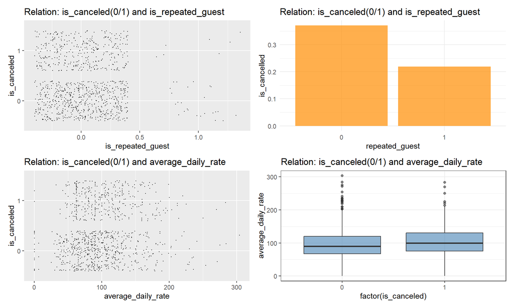

```r
(prq_j + prq_b) / (padr_j + padr_b)
```

## Úloha 13.6c)

**c)** Zapíš formálnou matematickou notáciou vhodný Bayesovský regresný model $Y$ pomocou prediktorov $(X_1, X_2, X_3, X_4)$.

**Dátový model**

**Bernoulliho rozdelenie pre binárnu premennú:**
$$Y_i | \beta_0, \beta_1, \beta_2, \beta_3, \beta_4
\sim \text{Bern}(\pi_i)$$

- kde $Y_i \in \{0, 1\}$ (zrušené / nezrušené)
- $\pi_i$ je pravdepodobnosť zrušenia rezervácie $i$.

**Logit linková funkcia**

**Log(odds) škála:**
$$\log\left(\frac{\pi_i}{1-\pi_i}\right) = \beta_0
+ \beta_1 X_{i1} + \beta_2 X_{i2} + \beta_3 X_{i3} + \beta_4
X_{i4}$$

- **Ľavá strana:** log(odds) zrušenia rezervácie
- **Pravá strana:** lineárna kombinácia prediktorov

**Transformácie**

**Odds škála:**
$$\frac{\pi_i}{1-\pi_i} = e^{\beta_0 + \beta_1
X_{i1} + \beta_2 X_{i2} + \beta_3 X_{i3} + \beta_4 X_{i4}}$$

**Pravdepodobnostná škála:**
$$\pi_i = \frac{e^{\beta_0 + \sum_{k=1}^{4} \beta_k
X_{ik}}}{1 + e^{\beta_0 + \sum_{k=1}^{4} \beta_k X_{ik}}}$$

## Úloha 13.6d)

**d)** Vysvetli tvoj výber štruktúry dátového modelu.

$Y_i$ je diskrétna premenná, ktorá može nadobúdať len hodnoty 0 alebo 1, najvhodnejší je **Bernoulliho model**

# Cvičenie 13.7: Simulácia modelu (Hotel bookings: simulation)

## Úloha 13.7a)

**a)** Simuluj posteriorný model regresných parametrov $(\beta_0, \beta_1, \ldots, \beta_4)$. Vytvor trace plots, density plots a `pp_check()` výstupu z reťazcov.

```r
# Run a prior simulation
hotel_model_1 <- stan_glm(
  is_canceled ~ lead_time + previous_cancellations +
                is_repeated_guest + average_daily_rate,
  data = hotel,
  family = binomial,
  prior_intercept = normal(-1.4, 0.7),
  prior = normal(0, 1, autoscale = TRUE),
  chains = 4, iter = 5000*2,
  refresh = 0
)
```

### Diagnostické grafy

**Trace plot (`mcmc_trace`):** - Kontroluje konvergenciu reťazcov - Dobré: “chlpaté” krivky, všetky reťazce sa prekrývajú - Zlé: trendy, uviaznuté reťazce, rôzne úrovne

**Density overlay (`mcmc_dens_overlay`):** - Kontroluje, či posteriorné hustoty z rôznych reťazcov sú podobné - Dobré: hustoty sa prekrývajú - Zlé: rozdielne tvary alebo polohy

**Autocorrelation (`mcmc_acf`):** - Kontroluje autokoreláciu v reťazcoch - Dobré: rýchlo klesá k nule - Zlé: vysoká autokorelácia na väčších lagoch

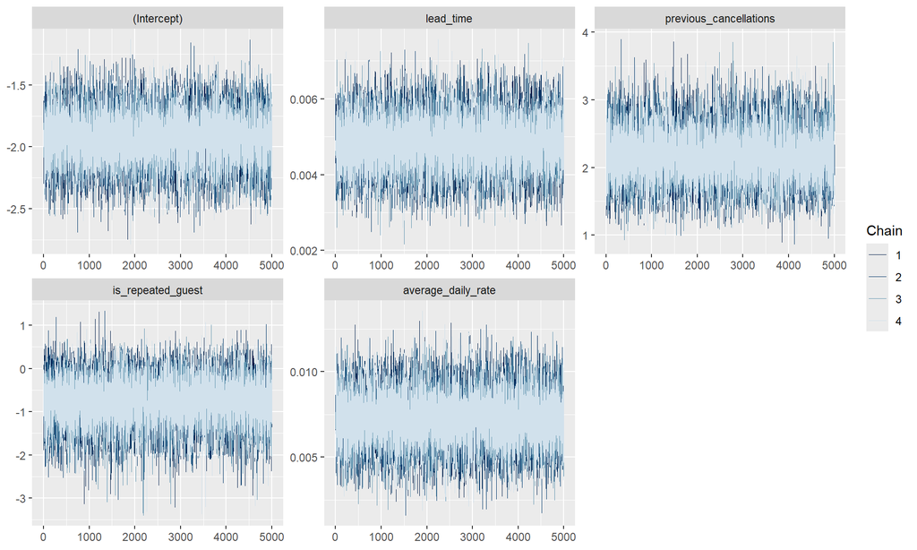

```r
# MCMC trace, density, & autocorrelation plots
hotel_model_1 |> mcmc_trace()
```

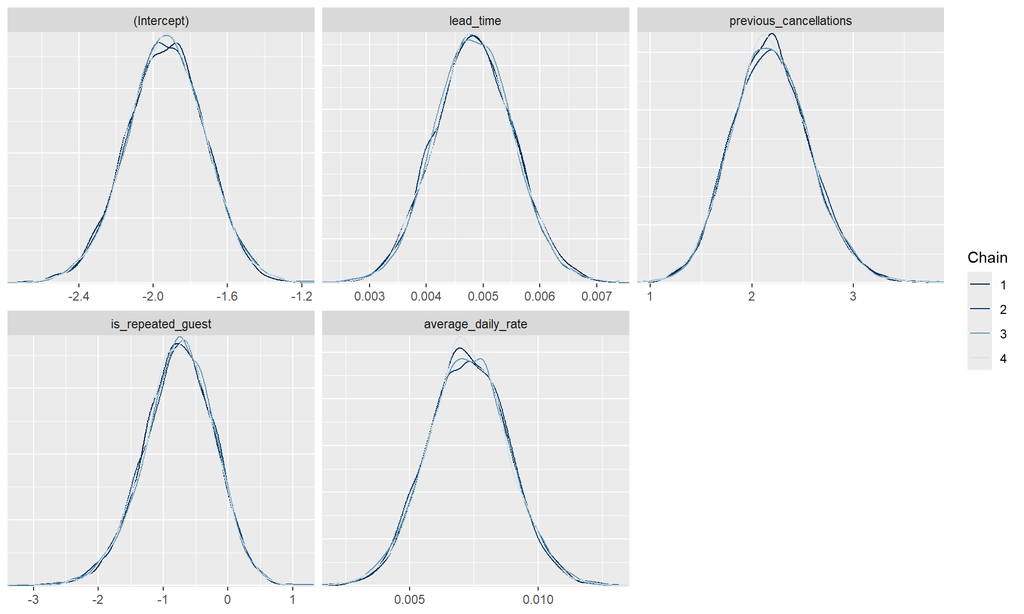

```r
hotel_model_1 |> mcmc_dens_overlay()
```

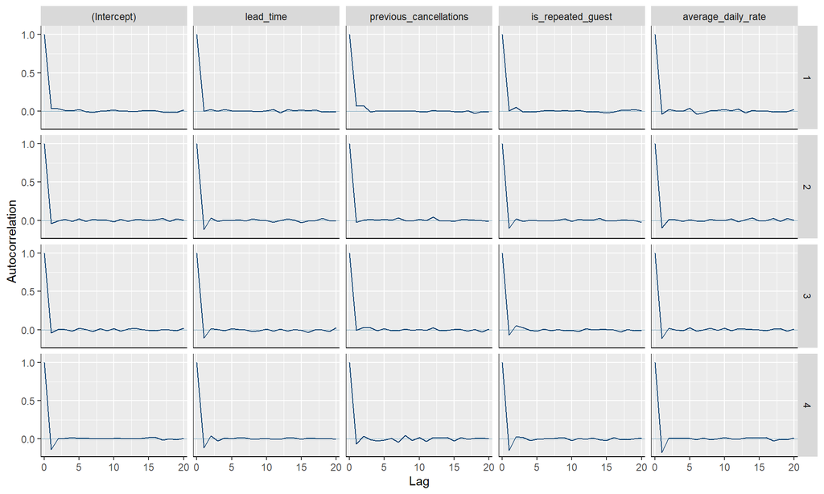

```r
hotel_model_1 |> mcmc_acf()
```

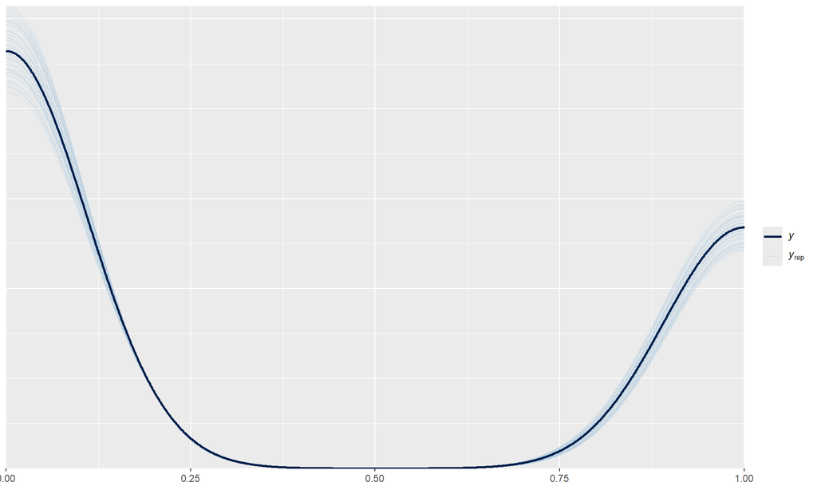

```r
hotel_model_1 |> pp_check()
```

### Numerické diagnostiky

**Effective sample size ratio (`neff_ratio`):** - Pomer efektívnej veľkosti vzorky k skutočnej - Dobré: > 0.1, ideálne blízko 1 - Zlé: < 0.1

**R-hat (`rhat`):** - Meria konvergenciu medzi reťazcami - Dobré: ≈ 1.00 (< 1.01) - Zlé: > 1.01

```r
neff_ratio(hotel_model_1)
```

```
##            (Intercept)              lead_time previous_cancellations
##                1.02200                1.09840                0.93920
##      is_repeated_guest     average_daily_rate
##                1.07545                1.15955
```

```r
rhat(hotel_model_1)
```

```
##            (Intercept)              lead_time previous_cancellations
##              0.9998938              0.9999786              0.9999601
##      is_repeated_guest     average_daily_rate
##              0.9999591              0.9998718
```

### Posterior predictive check

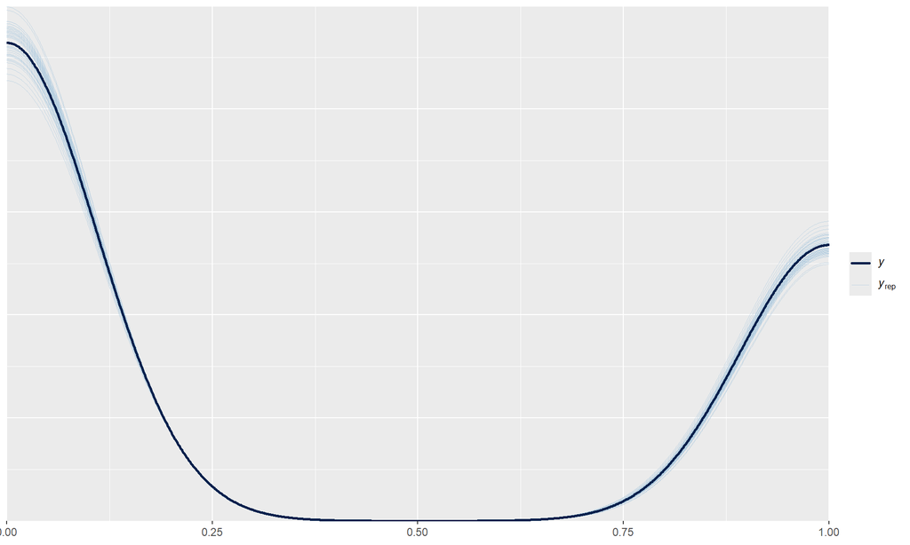

```r
# posterior predictive check
pp_check(hotel_model_1)
```

**Účel:** - Overuje, či simulované dáta z modelu sú podobné skutočným dátam - Kontroluje predpoklady modelu

**Interpretácia:** - Dobré: simulované hodnoty pokrývajú pozorovanú hodnotu - Zlé: pozorovaná hodnota je mimo rozsahu simulácií

## Úloha 13.7b)

**b)** Uveď posteriorný mediánový model hotelových zrušení na každej škále: log(odds), odds a pravdepodobnostnej.

Z MCMC simulácie mám 20,000 hodnôt pre každý koeficient (napr. $\beta_0$, $\beta_1$, $\beta_2$, …).Posteriorný mediánový model = model, kde použiješ mediány týchto posteriorných rozdelení namiesto priemerov.

**Mediánový model** použije **mediány** všetkých koeficientov:
$$\log\left(\frac{\pi}{1-\pi}\right) =
median(\beta_0) + median(\beta_1) X_{1} + ..$$
V R možnosť `tidy()` dáva MEAN, nie MEDIAN! - Tieto hodnoty můžeme zistiť z MCMC simulácie - alebo pomocou `posterior::summarise_draws()`

```r
library(posterior)
draws <- as_draws_df(hotel_model_1)
posterior_medians <- summarise_draws(draws, median)

# alebo z MCMC simulacie
# posterior_samples <- as.data.frame(hotel_model_1) # Extrahuj MCMC vzorky
# posterior_medians <- apply(posterior_samples, 2, median) # Vypočítaj mediány
posterior_medians
```

```
## # A tibble: 5 × 2
##   variable                 median
##   <chr>                     <dbl>
## 1 (Intercept)            -1.93
## 2 lead_time               0.00484
## 3 previous_cancellations  2.18
## 4 is_repeated_guest      -0.744
## 5 average_daily_rate      0.00725
```

```r
names(posterior_medians$median) <- posterior_medians$variable

beta0 <- posterior_medians$median["(Intercept)"] |> round(3)
beta1 <- posterior_medians$median["lead_time"] |> round(3)
beta2 <- posterior_medians$median["previous_cancellations"] |> round(3)
beta3 <- posterior_medians$median["is_repeated_guest"] |> round(3)
beta4 <- posterior_medians$median["average_daily_rate"] |> round(3)

exp_beta0 <- exp(beta0) |> round(3)
exp_beta1 <- exp(beta1) |> round(3)
exp_beta2 <- exp(beta2) |> round(3)
exp_beta3 <- exp(beta3) |> round(3)
exp_beta4 <- exp(beta4) |> round(3)
```

**Posterior credible intervals na log(odds) škále**

```r
tidy(hotel_model_1, effects = c("fixed"))
```

```
## # A tibble: 5 × 3
##   term                   estimate std.error
##   <chr>                     <dbl>     <dbl>
## 1 (Intercept)            -1.93     0.209
## 2 lead_time               0.00484  0.000692
## 3 previous_cancellations  2.18     0.380
## 4 is_repeated_guest      -0.744    0.537
## 5 average_daily_rate      0.00725  0.00156
```

```r
posterior_interval(hotel_model_1, prob = 0.80) |> round(3)
```

```
##                           10%    90%
## (Intercept)            -2.197 -1.662
## lead_time               0.004  0.006
## previous_cancellations  1.708  2.683
## is_repeated_guest      -1.472 -0.086
## average_daily_rate      0.005  0.009
```

**Posterior credible intervals na odds škále**

```r
exp(posterior_interval(hotel_model_1, prob = 0.80)) |> round(3)
```

```
##                          10%    90%
## (Intercept)            0.111  0.190
## lead_time              1.004  1.006
## previous_cancellations 5.515 14.632
## is_repeated_guest      0.229  0.918
## average_daily_rate     1.005  1.009
```

**Interpretácia:**

- $\beta_0 = -1.93$ (intercept)
- $\beta_1 = 0.005$ (lead_time): za každý deň navyše sa log(odds) zvýšia o 0.005
- $e^{\beta_1} = 1.005$ znamená, že odds sa vynásobia 1.005-krát (zvýšia o 0.5%)

## Úloha 13.7d)

**d)** Ktoré zo štyroch prediktorov sú štatisticky a vecne významne asociované so zrušením rezervácie? Vysvetli.

- štatistická významnosť: tie, kde 0 nie je v kredibilnom intervale
- vecná významnosť: má efekt praktický význam v reálnom svete?

[output not shown]

#### Vecná (praktická) významnosť

Pre posúdenie vecnej významnosti analyzujeme veľkosť efektov na odds škále:

```r
exp(posterior_interval(hotel_model_1, prob = 0.80))
```

```
##                              10%        90%
## (Intercept)            0.1110915  0.1897547
## lead_time              1.0039520  1.0057450
## previous_cancellations 5.5153075 14.6323418
## is_repeated_guest      0.2294349  0.9178699
## average_daily_rate     1.0052892  1.0093034
```

**1. `previous_cancellations` (predchádzajúce zrušenia)** - **VEĽMI SILNÝ efekt**

**2. `is_repeated_guest` (opakujúci sa hosť)** - **SILNÝ efekt**

**3. `lead_time` (počet dní dopredu)** - **MALÝ efekt** (vecne menej významný)

- $e^{\beta_1} \in [1.004, 1.006]$
- Za každý deň dopredu sa odds zvyšujú len o **0.4% až 0.6%**
- Musíš rezervovať ~140 dní vopred namiesto 0 dní, aby sa odds zdvojnásobili
- Štatisticky významný, ale praktický význam je malý

**4. `average_daily_rate` (priemerná denná cena)** - **MALÝ efekt** (vecne menej významný)

- $e^{\beta_4} \in [1.005, 1.009]$
- Za každý dolár navyše sa odds zvyšujú len o **0.5% až 0.9%**
- Musíš zvýšiť cenu o ~$100, aby sa odds zdvojnásobili
- Štatisticky významný, ale praktický význam je malý

# Cvičenie 13.8: Predikcia a klasifikácia

## Úloha a)

**a)** Ako dobre tvoj model predpovedá, či bude rezervácia zrušená? Evaluuj klasifikačnú presnosť pomocou in-sample aj krížovej validácie s pravdepodobnostným prahom 0.5. ### Posteriorná predikcia

Pre nové pozorovanie s prediktormi $X_{new}$:

$$Y_{new} | \beta_0, \beta_1, \ldots,
\beta_p \sim \text{Bern}(\pi_{new})$$

kde $\pi_{new}$ sa vypočíta z posteriorných hodnôt koeficientov.

### Klasifikačné pravidlo

Pre klasifikačný prah $c \in [0, 1]$:

- Ak $\hat{\pi} \geq c$, klasifikuj ako $Y = 1$
- Ak $\hat{\pi} < c$, klasifikuj ako $Y = 0$

kde $\hat{\pi}$ je priemerná posteriorná pravdepodobnosť.

### Confusion matrix

[output not shown]

[output not shown]

### Metriky presnosti

**Celková presnosť (Accuracy):**
$$\text{accuracy} = \frac{a + d}{a + b + c +
d}$$

**Citlivosť (Sensitivity / True Positive Rate):**
$$\text{sensitivity} = \frac{d}{c + d}$$
- Podiel správne identifikovaných pozitívnych prípadov ($Y = 1$) - “Ako dobre model identifikuje zrušené rezervácie?”

**Špecificita (Specificity / True Negative Rate):**
$$\text{specificity} = \frac{a}{a +
b}$$
- Podiel správne identifikovaných negatívnych prípadov ($Y = 0$) - “Ako dobre model identifikuje nezrušené rezervácie?”

### Trade-off

- **Zníženie prahu** $c$: ↑ sensitivity, ↓ specificity
- **Zvýšenie prahu** $c$: ↓ sensitivity, ↑ specificity

### Evaluácia klasifikačnej presnosti - MANUÁLNE

**KROK 1: Posteriorná predikcia pre všetky pozorovania** - Vytvoríme 20,000 predikcií (z MCMC) pre každú rezerváciu v datasete

```r
binary_prediction <- posterior_predict(hotel_model_1, newdata = hotel)
dim(binary_prediction)  # Ukáž rozmery
```

```
## [1] 20000  1000
```

- **Výsledok**: matica 20000 x n (n = počet rezervácií)
- **Každý stĺpec** = 20,000 predikcií (0 alebo 1) pre jednu rezerváciu

**KROK 2: Výpočet pravdepodobností zrušenia** - Pre každú rezerváciu: koľko % z 20,000 predikcií je “1” (zrušené)? - Toto je posteriorná pravdepodobnosť zrušenia

```r
probabilities <- colMeans(binary_prediction)
```

*Príklad*: ak 12,000 z 20,000 predikcií = 1, potom p = 0.6

Pozrime sa na prvých 10 pravdepodobností

```r
head(probabilities, 10)
```

```
##       1       2       3       4       5       6       7       8       9      10
## 0.55260 0.21285 0.37870 0.24755 0.57365 0.43320 0.09250 0.26165 0.33585 0.62730
```

**KROK 3: Klasifikácia s prahom 0.5** - Klasifikačné pravidlo: ak p >= 0.5, klasifikuj ako “zrušené” (1), inak “nezrušené” (0) Vytvoríme si tabuľku s výsledkami

```r
classifications <- as.numeric(probabilities >= 0.5)

results <- hotel %>%
  mutate(
    prob_cancel = probabilities,              # Posteriorná pravdepodobnosť
    predicted = classifications,              # Naša predikcia (0/1)
    actual = as.numeric(is_canceled)         # Skutočný výsledok (0/1)
  ) %>%
  select(actual, predicted, prob_cancel, everything())

# Pozrime sa na prvé riadky
results |> head(10)
```

```
## # A tibble: 10 × 8
##    actual predicted prob_cancel is_canceled lead_time previous_cancellations
##     <dbl>     <dbl>       <dbl> <fct>           <dbl>                  <dbl>
##  1      2         1      0.553  1                   1                      1
##  2      2         0      0.213  1                  19                      0
##  3      1         0      0.379  0                   9                      0
##  4      1         0      0.248  0                 110                      0
##  5      1         1      0.574  0                 329                      0
##  6      1         0      0.433  0                 212                      0
##  7      1         0      0.0925 0                  14                      0
##  8      1         0      0.262  0                  58                      0
##  9      2         0      0.336  1                  88                      0
## 10      2         1      0.627  1                 373                      0
## # ℹ 2 more variables: is_repeated_guest <dbl>, average_daily_rate <dbl>
```

**KROK 4: Confusion Matrix - MANUÁLNE**

```r
confusion <- table(Actual = results$actual, Predicted = results$predicted)
print(confusion)
```

```
##       Predicted
## Actual   0   1
##      1 576  58
##      2 251 115
```

[output not shown]

- a = True Negatives (správne predpovedané nezrušené)
- b = False Positives (nesprávne predpovedané ako zrušené)
- c = False Negatives (nesprávne predpovedané ako nezrušené)
- d = True Positives (správne predpovedané zrušené)

**KROK 5: Výpočet metrík - MATEMATIKA**

```r
a <- confusion[1, 1]  # True Negatives
b <- confusion[1, 2]  # False Positives
c <- confusion[2, 1]  # False Negatives
d <- confusion[2, 2]  # True Positives
```

**Overall Accuracy = (správne klasifikované) / (všetky)**

```r
accuracy <- (a + d) / (a + b + c + d)
```

**Sensitivity = (správne zrušené) / (všetky skutočne zrušené)**

```r
sensitivity <- d / (c + d)
```

**Specificity = (správne nezrušené) / (všetky skutočne nezrušené)**

```r
specificity <- a / (a + b)
```

**Confusion Matrix:**

```r
print(confusion)
```

```
##       Predicted
## Actual   0   1
##      1 576  58
##      2 251 115
```

```r
cat("True Negatives (a):", a, "\n")
```

```
## True Negatives (a): 576
```

```r
cat("False Positives (b):", b, "\n")
```

```
## False Positives (b): 58
```

```r
cat("False Negatives (c):", c, "\n")
```

```
## False Negatives (c): 251
```

```r
cat("True Positives (d):", d, "\n\n")
```

```
## True Positives (d): 115
```

```r
cat("Overall Accuracy:", round(accuracy, 4), "\n")
```

```
## Overall Accuracy: 0.691
```

```r
cat("Sensitivity:", round(sensitivity, 4), "\n")
```

```
## Sensitivity: 0.3142
```

```r
cat("Specificity:", round(specificity, 4), "\n\n")
```

```
## Specificity: 0.9085
```

**KROK 7: Krížová validácia** CV rozdelí dáta na 10 častí, 10x zopakuje: trénovanie na 9 častiach, testovanie na 1

```r
cv_result <- classification_summary_cv(model = hotel_model_1, data = hotel, cutoff = 0.5, k = 10)
print(cv_result$cv)
```

```
##   sensitivity specificity overall_accuracy
## 1   0.3024377   0.9097218            0.688
```

**Validácia za použitia funkcií**

```r
# In-sample klasifikácia (prah 0.5)
insample <- classification_summary(model = hotel_model_1, data = hotel, cutoff = 0.5)
insample
```

```
## $confusion_matrix
##  y   0   1
##  0 575  59
##  1 252 114
##
## $accuracy_rates
##
## sensitivity      0.3114754
## specificity      0.9069401
## overall_accuracy 0.6890000
```

```r
# Krížová validácia (prah 0.5, k = 10)
cv <- classification_summary_cv(model = hotel_model_1, data = hotel, cutoff = 0.5, k = 10)
cv
```

```
## $folds
##    fold sensitivity specificity overall_accuracy
## 1     1   0.3055556   0.9375000             0.71
## 2     2   0.2195122   0.8644068             0.60
## 3     3   0.4047619   0.9137931             0.70
## 4     4   0.2093023   0.9298246             0.62
## 5     5   0.3333333   0.9344262             0.70
## 6     6   0.3125000   0.8529412             0.68
## 7     7   0.2727273   0.8507463             0.66
## 8     8   0.3333333   0.9104478             0.72
## 9     9   0.2941176   0.9090909             0.70
## 10   10   0.2424242   0.8955224             0.68
##
## $cv
##   sensitivity specificity overall_accuracy
## 1   0.2927568   0.8998699            0.677
```

## Úloha 13.8b)

**b)** Sú krížovo-validované a in-sample odhady klasifikačnej presnosti podobné? Vysvetli, prečo má tento výsledok zmysel v kontexte tejto analýzy.

[output not shown]

**Vysvetlenie:**

Metriky sú takmer identické, čo naznačuje, že model **nie je overfittovaný** a dobre generalizuje na nové dáta.

*Poznámka:* [Ak by boli odlišné:] Model je overfittovaný - učí sa špecifiká trénovacích dát.

**Prečo to dáva zmysel v kontexte tejto analýzy:**

1. **Veľký dataset** - máme dostatočný počet rezervácií, takže model sa naučil skutočné vzory, nie náhodný šum v dátach
2. **Jednoduché prediktory** - používame len 4 prediktory, čo znižuje riziko overfittingu
3. **Silné signály** - prediktory ako `previous_cancellations` majú veľký efekt (e^β > 5), takže model zachytáva reálne a stabilné vzťahy
4. **Logistická regresia** - relatívne jednoduchý lineárny model s nízkym rizikom overfittingu

## Úloha 13.8c)

**c)** Interpretuj krížovo-validované celkové accuracy, sensitivity a specificity v kontexte tejto analýzy.

**Sensitivity (30.3%):** Z rezervácií, ktoré boli skutočne zrušené, model správne identifikoval len 30.3%. **To je nízka hodnota** - model má problém identifikovať zrušené rezervácie.

**Záver:** Model je **konzervatívny** - radšej klasifikuje rezervácie ako “nezrušené” a má tendenciu prehliadať skutočne zrušené rezervácie. S prahom 0.5 je málo citlivý na zrušenia. Pre zlepšenie sensitivity by bolo potrebné znížiť klasifikačný prah (napr. na 0.3 alebo 0.2).

**d)** Ako hotel booking agent by si chcela zvýšiť sensitivity tvojich klasifikácií na 0.75. Identifikuj pravdepodobnostný prah, ktorý môžeš použiť na dosiahnutie tejto úrovne pri zachovaní čo najvyššej špecificity.

**e)** Hosť, ktorý je nový v hoteli a zrušil rezerváciu len 1-krát predtým, si zarezervoval izbu za $100 denne 30 dní vopred. Simuluj, vykreli a diskutuj posteriorný prediktívny model $Y$, či hosť zruší túto rezerváciu.